# rapr: Representative and Adequate Prioritisations in R

Jeffrey O. Hanson, Jonathan R. Rhodes, Hugh P. Possingham, Richard A. Fuller

2015-11-17

## Abstract

A central aim in conservation is to maximise the long-term persistence of biodiversity. To achieve this, reserve networks are used to safeguard biodiversity patterns and processes. But resources are limited. Reserve selection is often formulated as an optimisation problem to identify cost-effective prioritisations. However, most existing decision support tools are based on formulations that are not well suited for preserving biodiversity processes. To fill this gap in the conservation planning toolbox, we developed the `rapr` R package. This R package uses two new novel formulations of the reserve selection problem to identify prioritisation. Here, we explore the package’s functionality using several simulated and a case-study in Queensland, Australia. We show how explicitly considering representativeness can alter a prioritisation.

## Introduction

The overarching aim of conservation to maximise the long-term persistence of biodiversity (McNeely 1994; Margules and Pressey 2000). To acheive this, conservation actions must preserve biodiversity patterns (eg. species, populations) and the processes that sustain them. One of the major tangible achievements of modern conservation has been the act of setting aside areas for preservation (Sanderson *et al.* 2015). Reserve networks buffer species from threatening processes (Moritz 2002) and set the stage for direct management interventions (eg. captive breeding and reintroduction programs; Kleiman 1989). However, the resources available for conservation action are limited, and so reserve networks must be sited in places that satisfy conservation objectives for minimum cost (Margules and Pressey 2000). To achieve this, reserve selection is often formulated as an optimisation problem and then solved to identify cost-effective candidate reserve systems (prioritisations; Margules and Pressey 2000).

To fulfil the overarching aims of conservation, reserve networks must preserve both ecological and evolutionary biodiversity processes (Margules and Pressey 2000; Crandall *et al.* 2000). Ecological processes are required for biodiversity to persist over short time-scales. Examples of these processes include predator-prey interactions, pollination, and decomposition. Typically, they operate over small geographic domains, with exceptions such as mirgation and refugial habitats, and can be preserved using suitably large planning units (Ciarleglio *et al.* 2009) that represent contiguous habitat (Klein *et al.* 2009). On the other hand, evolutionary processes are required for biodiversity to persist over long time-scales. Typically, they operate over large geographic domains. Adaptive evolutionary processes can be preserved by securing populations with different adaptations and/or along selection pressure gradients (eg. environmental gradients) (Moritz 2002). Neutral evolutionary processes can be be preserved by securing populations with different evolutionary histories and/or with limited gene flow (Moritz 2002). Due to advances in technology over the last few decades, a wealth of high quality data on biodiversity processes has become freely avaliable to conservation planners. Yet much of it is not being used for conservation planning (Hendry *et al.* 2010).

Existing decision support tools focus primarily on preserving biodiversity patterns or processes–but not both. Many tools have been developed to preserve biodiversity patterns (eg. C-Plan ( Pressey *et al.* 2009); ConsNet ( Ciarleglio *et al.* 2009); Marxan ( Ball *et al.* 2009); Zonation ( Moilanen 2007)). They use targets (eg. Marxan) or weights (eg. Zonation) to identify prioritisations that contain an adequate amount of individuals or habitat for a set of species (features). To accomodate some information on biodiversity processes, conservation planners can split features into sub-features as a pre-processing step (Carvalho *et al.* 2011). However, this approach is limited because data on biodiversity processes is often hyper-dimensional and continuous (eg. bioclimatic data; www.worldclim.org), and these problems cannot strucutre within and between sub-features (Faith and Walker 1996). On the other hand, very few tools have been developed with a specific focus on biodiversity processes. The DIVERSITY (Faith 2003) decision support tool continuous data to site reserves in places that secure a representative sample of variation (eg. environmental variation). However, unlike tools that focus on biodiversity patterns, this tool has can only accomodate data on the distribution of a single feature. Additionally, due to the nature of its formulation, this tool can often deliver prioritisaitons that are excssively fragmented.

Today, one of the key issues preventing decision makers from explicitly considering both biodiversity patterns and processes in the reserve seleciton process is the lack of a decision support tool that can accomodate data on both of them in a multi-species context. To fill this void, we present the `rapr` R package. This R package provides decision makers with the tools to identify, visaulise, and compare prioritisations. We develop two novel formulations of the reserve selection problem that use targets to ensure an adequate amount of habitat is preserved for each feature, and ensure that a sufficient proprotion of the diversity (eg. environmental, genetic, morphological) within each feature is also preserved. Finally, we provide a tutorial showcasing the functionality of this R package using three simulated species and a case-study species.

## Problem formulations

The `rapr` R package uses two novel formulations of the reserve selection problem to identify cost-effective prioritisations. Biodiversity features are defined as the entity(s) that the prioritisation is required to preserve. Spatial attributes are defined as the intra-feature variation that the prioritisation is required to sample. These attributes may be related to intra-feature biodiversity patterns, such as morphological or genetic variation within a species, or related to the processes that sustain intra-feature biodiversity patterns, such as environmental variation.

Each attribute is conceptualised as a space–an attribute space–and planning units are thought to occupy points inside each space. For example, a decision maker may require a prioritisation that preserves populations along climatic gradients. To achieve this, the decision maker might use an “climatic” attribute space with dimensions relating to mean annual temperature ($^{\circ}$C) and precipitation (mm). Any given combination of temperature and precipitation may be conceived as a point in this environmental space. By associating planning units with climatic data, they can be mapped from geographic space to this environmental attribute space.

Demand points are points that exist in an attribute space. They are designated by the decision maker to indicate regions of the attribute space that should be preserved in the prioritisation. The degree to which a prioritisation represents a spatial attribute is a function of the distance between each demand point and each planning unit in the attribute space. The shorter the distances between the demand points and the planning units; the better the prioritisation is a representing the variation in the spatial attribute. In any attribute space there may exist points that are impossible (eg. mean annual rainfall -5 mm), do not occur in the study area (eg. mean annual temperature 30$^{\circ}$C in Antarctica), or are undesirable (eg. conditions known to be outside the physiological tolerance of a species). By placing demand points in desirable regions of an attribute space, the decision maker can ensure that prioritisations secure desirable values of a spatial attribute.

To illustrate these concepts, we will briefly describe a conservation planning scenario example involving attribute spaces and demand points. A decision maker may wish to develop a prioritisation for a single species. This species has four populations in the study area. These populations are in the process of divergent evolution, with different populations inhabiting different environmental conditions and accruing different adaptations. However, the decision maker can only afford to preserve three of the populations. The decision maker needs to select a set of populations that will be representative in terms of the species’ intra-specific variation. To describe this intra-specific variation, the decision maker obtained data on the environmental conditions (rainfall (ml) and temperature ($^{\circ}$C) where each population was found. The decision maker then used this environmental data to construct a two-dimensional environmental attribute space. Next, the decision maker generated demand points as equi-distant points between the range of values where the populations were found ($\pm$ 20% to avoid edge effects, see (Faith and Walker 1996)). By comparing the distribution of the demand points to the distribution of the populations in the attribute space, the decision maker can identify a suitable prioritisation (Figure 1). We can see that if the decision maker preserves both popuations $A$ and $C$ in the same prioritisation, they will effectively “double-up” on the same genetic variation, and in turn their waste resources. Instead, a representative sample of the species intra-specific variation can be preserved by securing populations $A$, $B$, and $D$.

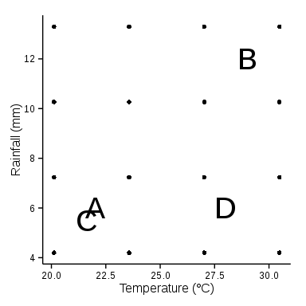

The reserve selection problems are based on uncapacitated facility location problems (all mathematical terms defined hereafter are described in Table S1 for convenience). For convenience, the cardinality of sets will be denoted using the same symbol used to denote the variable. Define $F$ to be the set of features (indexed by $f$). Let $J$ be a set of planning units (indexed by $j$). Also, let $A_j$ denote the area, and $c_j$ denote the cost of preserving planning unit $j \in J$. To assess the extent to which each feature is secured in a given prioritisation, let $q_{fj}$ denote the probability of feature $f$ occupying planning unit $j$. The level of fragmentation associated with a prioritisation is parametrised as the net exposed boundary length. Let the shared boundary length between each planning unit $j \in J$ and $k \in J$ be $b_{jk}$. In any real-world problem, some planning units will have edges that are not associated with any neighbouring planning units (eg. edges along coastlines), these cases will be denoted using $b_{jj}$ for $j \in J$.

Let $S$ denote a set of attribute spaces (indexed by $s$). Each $j \in J$ is associated with spatially explicit data that represent coordinates for each attribute space $s \in S$. Let $I_{fsi}$ denote a set of demand points (indexed by $i$) for each feature $f \in F$ and each attribute space $s \in S$. Let $\lambda_{fsi}$ denote the weighting for each demand point $i \in I$ for each feature $f \in F$ and each attribute space $s \in S$. Let $d_{fsij}$ denote the distance between each demand point $i \in I$ and each planning unit $j \in J$ for each feature $f \in F$ and attribute space $s \in S$. The decision maker will need to choose an appropriate distance metric for each attribute space. For example, Euclidean, Mahalanobis (Mahalanobis 1936), Bray-Curtis, or other distance metrics may be appropriate given the nature of the attribute space (Faith *et al.* 1987).

Targets are used to ensure that prioritisations are sufficient in terms of their adequacy and representativeness. Let $\hat{T}_f$ denote the expected amount of area that needs to be preserved for each feature $f \in F$. Let $\bar{T}_{fs}$ denote the representativeness targets for feature $f \in F$ and attribute space $a \in A$. For convenience, these targets are expressed as proportions in the R package between the values for the worst possible prioritisation and the prioritisation that includes all the planning units.

These formulations are based on the unreliable (Fernández and Landete 2015) and reliable uncapacitated facility location (Cui *et al.* 2010) the problems. The key difference between these formulations is that the reliable formulation explicitly considers the probability that the planning units are occupied when determining the level of representation that a prioritisation secures, and the unreliable formulation does not. As a consequence, the unreliable formulation is simpler and can be solved in a short period of time.

### Unreliable formulation

The control variables in the unreliable formulation are the $X$, $BLM$, $\hat{t}_{s}$, and $\bar{t}_{sa}$ variables.

$\begin{align*} X_j &= \begin{cases} 1, & \text{if planning unit $j$ is selected for conservation action} \tag{1a} \\ 0, & \text{otherwise} \\ \end{cases} \\ % \hat{T}_s &= \text{amount target for feature $f$} \tag{1b}\\ % \bar{T}_{sa} &= \text{representation target for feature $f$ in attribute space $a$} \tag{1c}\\ % BLM &= \text{boundary length modifier} \tag{1d}\\ \end{align*}$

The unreliable formulation (URAP) is a multi-objective optimisation problem.

$\begin{align*} & \text{(URAP)} & \text{Min } & \sum_{j=0}^{J-1} C_j + BLM \times \sum_{j=0}^{J-1} \sum_{k=j}^{J-1} X_j \left( 1-X_k \right) b_{jk} + BLM \times \sum_{j=0}^{J-1} x_j b_{jj} & & \tag{2a}\\ % & & \text{s.t. } & \sum_{j=0}^{J-1} A_j q_{jf} \geq \bar{T}_{f} & \forall & 0 \leq f \leq F-1 \tag{2b}\\ % & & & \sum_{i=0}^{I-1} \sum_{j=0}^{J-1} \lambda_{fsi} Y_{fsij} \leq \hat{T}_{fs} & \forall & 0 \leq f \leq F-1, \tag{2c}\\ & & & & & 0 \leq s \leq S-1\\ % & & & \sum_{j=0}^{J-1} Y_{fsij} = 1 & \forall & 0 \leq f \leq F-1, \tag{2d}\\ & & & & & 0 \leq s \leq S-1, \\ & & & & & 0 \leq i \leq I-1\\ % & & & Y_{fsij} \leq X_j & \forall & 0 \leq f \leq F-1, \tag{2e}\\ & & & & & 0 \leq s \leq S-1, \\ & & & & & 0 \leq i \leq I-1,\\ & & & & & 0 \leq j \leq J-1\\ % & & & X_j, Y_{fsij} \in {0,1} & \forall & 0 \leq f \leq F-1, \tag{2f}\\ & & & & & 0 \leq s \leq S-1,\\ & & & & & 0 \leq i \leq I-1\\ % \end{align*}$

The objective function (2a) determines the utility of a given prioritisation: a combination of the total cost of a prioritisation and how fragmented it is. Constraints (2b–2c) ensure that all the amount-based and space-based targets are met. Constraints (2d) ensure that only one planning unit is assigned to each demand point. Constraints (2e) ensure that demand points are only assigned to selected planning units. Constraints (2f) ensure that the $X$ and $Y$ variables are binary.

### Reliable formulation

The reliable formulation explicitly considers the probability that the planning units are inhabited. As a consequence, it can deliver prioritisations that will sufficiently represent an attribute space even if the features do not inhabit several of the planning units when the prioritisation is implemented. This behaviour is achevied by siting back-up planning units near planning units with low occupancy probabilities in the attribute space(s). To ensure that prioritisations are robust against multiple planning units being uninhabited, the problem assigns demand points at multiple backup $r$-levels (similar to failure levels in Snyder and Daskin 2005).

The first backup $r$-level is used to calculate the level of representation when all of the selected planning units are occupied by all $f \in F$. For this scenario, the closest selected planning unit to each demand point $i$ for attribute space $s$ is assigned at $r$-level$=0$. This scenario essentially represents $Y_{fsij}$ in the unreliable formulation. The second backup $r$-level is used to assess the level of representation when the closest planning unit to each demand point $i$ is unoccupied. For this scenario, the second closest planning units are assigned at $r$-level$=1$. The third backup $r$-level is used to assess the representation when both the first two closest planning units are unoccupied. The third closest planning units are assigned at $r$-level$=2$. Continuing on, in this manner, the selected planning units in a prioritisation are assigned to each demand point $i \in I$, attribute space $s \in S$, and each feature $f \in F$ at an $r$-level.

A final backup $r$-level when $r=R$ is used to assess the level of representation when the features $f \in F$ do not occupy any selected planning units in a prioritisation. Each demand point $i \in I$ for each $s \in S$ and $f \in F$ is assigned to an “imaginary” planning unit $j=J$ at $r=R$. The distance variables associated with this imaginary planning unit $d_{fsiJ}$ denote the loss of biological value associated with failing to secure a representative sample of feature $f$ in attribute space $s$. However, the $d$ variables are in distance units which are meangingless units in this context. Thus these variables are calculated using a failure multiplier ($M$) and the maximum distance between the planning units and the demand points for $f \in F$, $s \in S$ (3).

$\begin{align*} & d_{fsiJ} = M \times \max\limits_{0 \leq i \leq I-1, 0 \leq j \leq J-1} d_{fsij} & \forall & 0 \leq f \leq F-1, \tag{3} \\ & & & 0 \leq s \leq S-1\\ \end{align*}$

Moderately-sized conservation planning problems often include several thousand planning units. It would simply not be feasible to solve this problem when considering all possible failure scenarios. As a consequence, the $R$ variable can be any $1 \leq R \leq J-1$. For instance, when $R=3$ only 2 backup levels are considered in addition to the final backup level. Cui et al. (2010) found that $R=5$ yields similar solutions to $R=J$ when $J >> 5$. However, depending on the number of features, demand points, attribute spaces, and planning units, decision makers will likely be limited to $R=1$.

The control variables in the reliable formulation are the $X$, $BLM$, $\hat{t}_{s}$, $\bar{t}_{sa}$, $R$, and $M$ variables.

$\begin{align*} & \text{(1a--1d)} \\ R &= \text{number of failure levels} \tag{4a} \\ % M &= \text{failure multiplier} \tag{4b}\\ % \end{align*}$

The reliable formulation (RRAP) is a multi-objective optimisation problem.

$\begin{align*} & \text{(RRAP)} & \text{Min } & \text{(2a)}\\ % & & \text{s.t. } & \text{(2b)}\\ % & & & \sum_{i=0}^{I-1} \sum_{j=0}^{J} \sum_{r=0}^{R} \lambda_{fsijr} P_{fsijr} Y_{fsijr} \leq \hat{T}_{fs} & \forall & 0 \leq f \leq F-1, \tag{5a}\\ & & & & & 0 \leq s \leq S-1\\ % & & & \sum_{j=0}^{J-1} Y_{fsijr} = 1 & \forall & 0 \leq f \leq F-1, \tag{5b}\\ & & & & & 0 \leq s \leq S-1,\\ & & & & & 0 \leq i \leq I-1,\\ & & & & & 0 \leq r \leq R\\ % & & & \sum_{r=0}^{R} Y_{fsijr} = 1 & \forall & 0 \leq f \leq F-1, \tag{5c}\\ & & & & & 0 \leq s \leq S-1,\\ & & & & & 0 \leq i \leq I-1,\\ & & & & & 0 \leq j \leq J\\ % & & & \sum_{r=0}^{R-1} Y_{fsijr} \leq X_j & \forall & 0 \leq f \leq F-1, \tag{5d}\\ & & & & & 0 \leq s \leq S-1,\\ & & & & & 0 \leq i \leq I-1,\\ & & & & & 0 \leq j \leq J-1\\ % & & & Y_{fsiJR} = 1 & \forall & 0 \leq f \leq F-1, \tag{5e}\\ & & & & & 0 \leq s \leq S-1,\\ & & & & & 0 \leq i \leq I-1\\ % & & & P_{fsij0} = q_{fj} & \forall & 0 \leq f \leq F-1, \tag{5f}\\ & & & & & 0 \leq s \leq S-1,\\ & & & & & 0 \leq i \leq I-1,\\ & & & & & 0 \leq j \leq J\\ % & & & P_{fsijr} = \left(1 - \right) \sum_{k=0}^{J-1} \frac{1 - q_k}{q_k} P_{f,s,i,k,r-1} Y_{f,s,i,k,r-1} & \forall & 0 \leq f \leq F-1, \tag{5g}\\ & & & & & 0 \leq s \leq S-1,\\ & & & & & 0 \leq i \leq I-1,\\ & & & & & 0 \leq j \leq J,\\ & & & & & 1 \leq r \leq R\\ % & & & X_j, Y_{fsijr} \in {0,1} & \forall & 0 \leq f \leq F-1, \tag{5h}\\ & & & & & 0 \leq s \leq S-1,\\ & & & & & 0 \leq i \leq I-1,\\ & & & & & 0 \leq j \leq J,\\ & & & & & 0 \leq r \leq R\\ \end{align*}$

The objective function for the reliable formulation is the same as for the unreliable formation (2a). Similar to the unreliable formulation, constraints (2b) and (5a) ensure that the amount-based and space-based targets are met. Constraint (5b–5c) ensure that each planning unit is only assigned to one backup $r$-level for $i \in I$. Constraints (5d) ensure that only selected planning units are assigned to demand points $i \in I$. Constraints (5e) ensure that the imaginary planning unit is always assigned to the highest backup $r$-level. Constraints (5f–5g) determine the probability that planing unit $j$ will be used to sample demand point $i \in I$ for $s \in S$ and $f \in F$ (Cui *et al.* 2010). Constraints (5h) ensure that the $X$ and $Y$ variables are binary.

### Optimisation

The unreliable and reliable formulations are non-linear. However, the non-linear components can be linearised using existing techniques. First, the expression $X_j X_k$ in (2a) can be linearised using methods described by Beyer et al. (2015). Second, the expression $P_{fsijr} Y_{jsijr}$ in (4a) can be linearised using techniques described by Sherali and Alameddine (1992) as implemented in Cui et al. (2010). Linearised versions of the problem can be solved using commerical exact algorithm solvers (eg. [IBM CPLEX](http://www.ibm.com/software/commerce/optimization/cplex-optimizer); [Gurobi](http://www.gurobi.com)).

The `rapr` R package provides functions to express conservation planning data as an optimisation problems using linearised versions of the unreliable and reliable formulations. These optimisation problems can then be solved to generate prioritisations using the commercial [Gurobi](http://www.gurobi.com) software package. Note that academics can easily obtain a [license at no cost after registering on the Gurobi website](http://user.gurobi.com/download/licenses/free-academic). After installing the Gurobi software packages, users will need to install the `Gurobi` R package. This R package can be installed on [Windows](http://www.gurobi.com/documentation/6.5/quickstart_windows/r_installing_the_r_package.html), [Mac OSX](http://www.gurobi.com/documentation/6.5/quickstart_mac/r_installing_the_r_package.html), or [Linux](http://www.gurobi.com/documentation/6.5/quickstart_linux/r_installing_the_r_package.html) operating systems.

## Package overview

To load the `rapr` R package and learn more about the package, type the following code into R.

```r
# load rapr R package
library(rapr)

# show package overview
?rapr
```

The `rapr` R package uses a range of S4 classes to store conservation planning data, parameters, and prioritisations (Table 1).

Table 1: Classes in `rapr` R package

| Class Name | Description | Slots |
| --- | --- | --- |
| ManualOpts | place-holder class for manually specified solutions | NumberSolutions |
| GurobiOpts | parameters for solving optimisation problems using Gurobi | Threads, MIPGap, Presolve, TimeLimit, NumberSolutions |
| RapUnreliableOpts | parameters for the unreliable problem formulation | BLM |
| RapReliableOpts | parameters for the reliable problem formulation | failure.multiplier, max.r.level |
| SimplePoints | stores coordinates in an n-dimensional space | coords |
| DemandPoints | demand points coordinates and weights for a species in an attribute space | points, weights |
| AttributeSpace | planning unit coordinates and demand points data for an attribute space | pu, demand.points, distance.metric |
| RapData | planning unit, species, and attribute space data | pu, species, targets, pu.species.probabilities, attribute.spaces, boundary, polygons, .cache |
| RapUnsolved | data and parameters needed to generate prioritisations using RAP | opts, data |
| RapResults | prioritisations and summary statistics | summary, selections, amount.held, space.held, logging.file, .cache |
| RapSolved | data, parameters, and prioritisations using them | opts, data, results |

## Simulated examples

### Data

To investigate the behaviour of the problem, we will generate prioritisations for three simulated species. We will use the unreliable formulation of the problem to understand the basics, and later move onto the reliable formulation. The first species (termed ‘uniform’) will represent a hyper-generalist. This species will inhabit all areas with equal probability. The second species (termed ‘normal’) will represent a species with a single range core. The third species (termed ‘bimodal’) will represent a species with two distinct ecotypes, each with their own range core. To reduce computational time for this example, we will use a 10 $\times$ 10 grid of square planning units.

```r
# make planning units
sim_pus <- sim.pus(100L)

# simulate species distributions
sim_spp <- lapply(
    c('uniform', 'normal', 'bimodal'),
    sim.species,
  n=1,
  x=sim_pus,
  res=1
)
```

Let’s see what these species’ distributions look like. Each square represents a planning unit, and the color of each denotes square denotes the probability of the species in the planning unit.

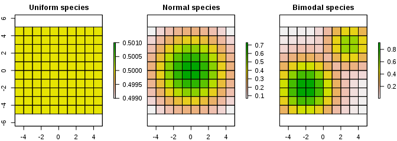

```r
# plot species
plot(
    stack(sim_spp),
    main=c('Uniform species','Normal species','Bimodal species'),
    addfun=function(){lines(sim_pus)},
    nc=3
)
```

Next, we will generate a set of demand points. To understand the effects of probabilities and weights on the demand points, we will generate the demand points in geographic space. These demand points will be the centroids of the planning units. Additionally, we will use the same set of demand points for each species and only vary the weights of the demand points between species. **Note that we are only using the same distribution of demand points for different species for teaching purposes. It is strongly recomended to use different demand points for different species in real-world conservation planning exercises.**

```r
# generate coordinates for pus/demand points
pu_coords <- rgeos::gCentroid(sim_pus, byid=TRUE)

# calculate weights
sim_dps <- lapply(
    sim_spp,
    function(x) {
        return(extract(x, pu_coords))
    }
)

# create demand point objects
sim_dps <- lapply(
    sim_dps,
    function(x) {
        return(
            DemandPoints(
                SimplePoints(pu_coords@coords),
                c(x)
            )
        )
    }
)
```

Now, we will construct a `RapUnsolved` object to store our input data and parameters. This contains all the information to generate prioritisations.

```r
## create RapUnreliableOpts object
# this stores parameters for the unreliable formulation problem (eg. BLM)
sim_ro <- RapUnreliableOpts()

## create RapData object
# create data.frame with species info
species <- data.frame(
  name=c('uniform', 'normal', 'bimodal')
)

## create data.frame with species and space targets
# amount targets at 20% (denoted with target=0)
# space targets at 20% (denoted with target=1)
targets <- expand.grid(
  species=1:3,
  target=0:1,
  proportion=0.2
)

# calculate probability of each species in each pu
pu_probabilities <- calcSpeciesAverageInPus(sim_pus, stack(sim_spp))

## create AttributeSpace object
# this stores the coordinates of the planning units in an attribute space
# and the coordinates and weights of demand points in the space
attr_space <- AttributeSpace(
  SimplePoints(pu_coords@coords),
  sim_dps
)

# generate boundary data information
boundary <- calcBoundaryData(sim_pus)

## create RapData object
# this store all the input data for the prioritisation
sim_rd <- RapData(
  sim_pus@data,
  species,
  targets,
  pu_probabilities,
  list(attr_space),
  boundary,
  SpatialPolygons2PolySet(sim_pus)
)

## create RapUnsolved object
# this store all the input data and parameters needed to generate prioritisations
sim_ru <- RapUnsolved(sim_ro, sim_rd)
```

### Single-species prioritisations

#### Amount-based targets

Let’s keep things simple to start off with. First we will generate a prioritisation for each species using only amount-based targets. Then, we will generate prioritisations for each species using a combination of amount-based and space-based targets. We will then compare the prioritisations to see how they differ to see how including space-based targets can change prioritisaitons under the simplest of circumstances.

Now we will generate a prioritisation for the uniform species using amount-based targets. To do this we will generate a new `sim_ru` object by subsetting out the data for the uniform species from the `sim_ru` object containing data for all the species. Then, we will update the targets in the new object. Finally, we will solve the object to generate a prioritisation that fulfills the targets for minimal cost.

```r
# create new object with just the uniform species
sim_ru_s1 <- spp.subset(sim_ru, 'uniform')

# update amount targets to 20% and space targets to 0%
sim_ru_s1 <- update(sim_ru_s1, amount.target=0.2, space.target=0, solve=FALSE)
```

```r
# solve problem to identify prioritisation
sim_rs_s1_amount <- solve(sim_ru_s1)
```

```
## Optimize a model with 1 rows, 100 columns and 100 nonzeros
## Coefficient statistics:
##   Matrix range    [5e-01, 5e-01]
##   Objective range [1e+00, 1e+00]
##   Bounds range    [1e+00, 1e+00]
##   RHS range       [1e+01, 1e+01]
## Found heuristic solution: objective 20
## Presolve removed 1 rows and 100 columns
## Presolve time: 0.00s
## Presolve: All rows and columns removed
##
## Explored 0 nodes (0 simplex iterations) in 0.00 seconds
## Thread count was 1 (of 2 available processors)
##
## Optimal solution found (tolerance 5.00e-02)
## Best objective 2.000000000000e+01, best bound 2.000000000000e+01, gap 0.0%
```

```r
## show summary
# note the format for this is identical to that used by Marxan
summary(sim_rs_s1_amount)
```

```
##   Run_Number Score Cost Planning_Units Connectivity_Total Connectivity_In
## 1          1    20   20             20                220              42
##   Connectivity_Edge Connectivity_Out Connectivity_In_Fraction
## 1               168               10                0.1909091
```

```r
# show amount held
amount.held(sim_rs_s1_amount)
```

```
##   uniform
## 1     0.2
```

```r
# show space held
space.held(sim_rs_s1_amount)
```

```
##   uniform (Space 1)
## 1         0.4859379
```

Now that we have generated a prioritisation, we will see what it looks like. We can use the `plot` method to visualise the spatial distribution of the planning units. Planning units with a dark green fill are selected for prioritisation, and those with a pale green color are not.

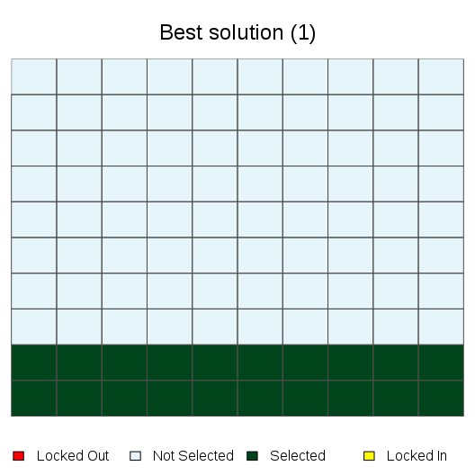

```r
# plot the first (and only) solution in the prioritisation
plot(sim_rs_s1_amount, 1)
```

We can use the `spp.plot` method to see how the prioritisation overlaps with the uniform species’ distribution. The fill of the planning units indicates the probability that they are occupied by the species. Since all planning units have equal probabilities for this species, all planning units have the same fill. Planning units with a green border are included for prioritisation.

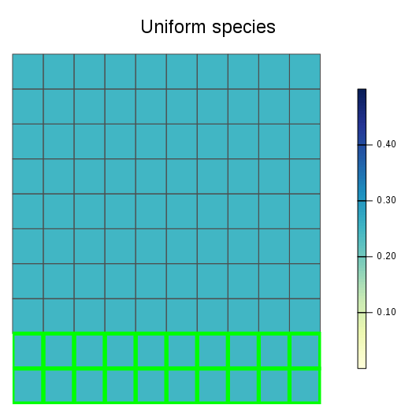

```r
# plot the prioritisation and the uniform species' distribution
spp.plot(sim_rs_s1_amount, 1, main='Uniform species')
```

The prioritisation for the uniform species appears to be just a random selection of planning units. This behavior is due to the fact that any prioritisation with 20 planning units is optimal. By relying on just amount targets, this solution may preserve a section of the species’ range core, or just focus on the range margin, or some random part of its range–no emphasis is directed towards preserving different parts of the species’ range. This behavior highlights a fundamental limitation of just using amount-based targets. In the absence of additional criteria, conventional reserve selection problems do not contain any additional information to identify the most effective prioritisation.

Now, we will generate a prioritisation for the normally distributed species using amount-targets. We will use a similar process to what we used for the uniformly distributed species, but for brevity, we will generate solutions immediately after updating the object.

```r
# create new object with just the normal species
sim_ru_s2 <- spp.subset(sim_ru, 'normal')
```

```r
# update amount targets to 20% and space targets to 0% and solve it
sim_rs_s2_amount <- update(sim_ru_s2, amount.target=0.2, space.target=0, solve=TRUE)
```

```
## Optimize a model with 1 rows, 100 columns and 100 nonzeros
## Coefficient statistics:
##   Matrix range    [7e-02, 7e-01]
##   Objective range [1e+00, 1e+00]
##   Bounds range    [1e+00, 1e+00]
##   RHS range       [7e+00, 7e+00]
## Found heuristic solution: objective 27
## Presolve removed 0 rows and 86 columns
## Presolve time: 0.01s
## Presolved: 1 rows, 14 columns, 14 nonzeros
## Variable types: 0 continuous, 14 integer (0 binary)
## Presolved: 1 rows, 14 columns, 14 nonzeros
##
##
## Root relaxation: objective 9.864476e+00, 1 iterations, 0.01 seconds
##
##     Nodes    |    Current Node    |     Objective Bounds      |     Work
##  Expl Unexpl |  Obj  Depth IntInf | Incumbent    BestBd   Gap | It/Node Time
##
##      0     0    9.86448    0    1   27.00000    9.86448  63.5%     -    0s
## H    0     0                      10.0000000    9.86448  1.36%     -    0s
##
## Explored 0 nodes (1 simplex iterations) in 0.03 seconds
## Thread count was 1 (of 2 available processors)
##
## Optimal solution found (tolerance 5.00e-02)
## Best objective 1.000000000000e+01, best bound 1.000000000000e+01, gap 0.0%
```

```r
# show summary
summary(sim_rs_s2_amount)
```

```
##   Run_Number Score Cost Planning_Units Connectivity_Total Connectivity_In
## 1          1    10   10             10                220              12
##   Connectivity_Edge Connectivity_Out Connectivity_In_Fraction
## 1               192               16               0.05454545
```

```r
# show amount held
amount.held(sim_rs_s2_amount)
```

```
##      normal
## 1 0.2026153
```

```r
# show space held
space.held(sim_rs_s2_amount)
```

```
##   normal (Space 1)
## 1        0.7456508
```

Now let’s visualise the prioritisation we made for the normal species.

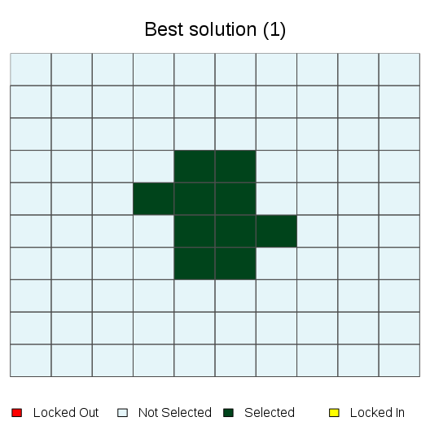

```r
# plot the prioritisation
plot(sim_rs_s2_amount, 1)
```

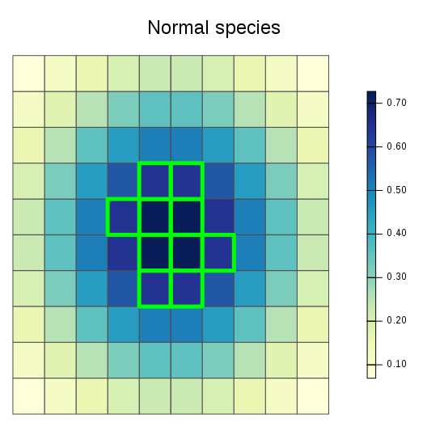

```r
# plot the prioritisation and the normal species' distribution
spp.plot(sim_rs_s2_amount, 1, main='Normal species')
```

The amount-based prioritisation for the normal species focuses only on the species’ range core. This prioritisation fails to secure any peripheral parts of the species’ distribution. As a consequence, it may miss out on populations with novel adaptations to environmental conditions along the species’ range margin.

Now, let’s generate an amount-based target for the bimodally distributed species, and visualise it.

```r
# create new object with just the bimodal species
sim_ru_s3 <- spp.subset(sim_ru, 'bimodal')
```

```r
# update amount targets to 20% and space targets to 0% and solve it
sim_rs_s3_amount <- update(sim_ru_s3, amount.target=0.2, space.target=0)
```

```
## Optimize a model with 1 rows, 100 columns and 100 nonzeros
## Coefficient statistics:
##   Matrix range    [7e-03, 9e-01]
##   Objective range [1e+00, 1e+00]
##   Bounds range    [1e+00, 1e+00]
##   RHS range       [7e+00, 7e+00]
## Found heuristic solution: objective 21
## Presolve removed 0 rows and 75 columns
## Presolve time: 0.00s
## Presolved: 1 rows, 25 columns, 25 nonzeros
## Variable types: 0 continuous, 25 integer (0 binary)
## Presolved: 1 rows, 25 columns, 25 nonzeros
##
##
## Root relaxation: objective 7.919039e+00, 1 iterations, 0.00 seconds
##
##     Nodes    |    Current Node    |     Objective Bounds      |     Work
##  Expl Unexpl |  Obj  Depth IntInf | Incumbent    BestBd   Gap | It/Node Time
##
##      0     0    7.91904    0    1   21.00000    7.91904  62.3%     -    0s
## H    0     0                       8.0000000    7.91904  1.01%     -    0s
##
## Explored 0 nodes (1 simplex iterations) in 0.00 seconds
## Thread count was 1 (of 2 available processors)
##
## Optimal solution found (tolerance 5.00e-02)
## Best objective 8.000000000000e+00, best bound 8.000000000000e+00, gap 0.0%
```

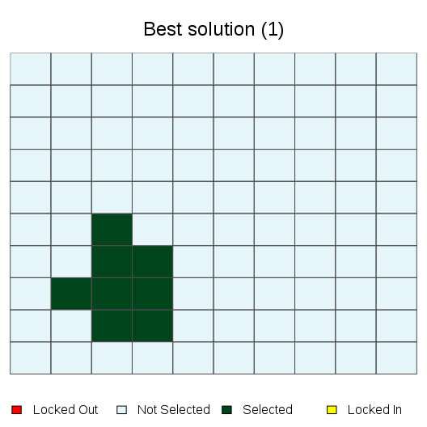

```r
# plot the prioritisation
plot(sim_rs_s3_amount, 1)
```

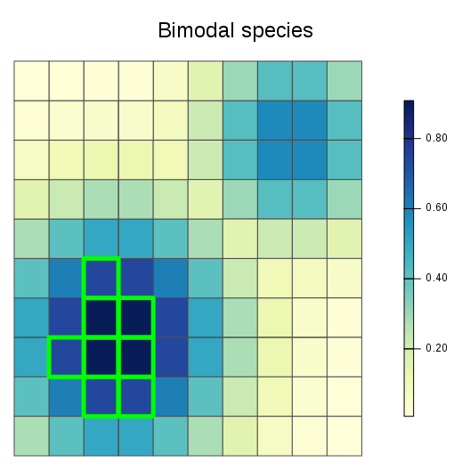

```r
# plot the prioritisation and the bimodal species' distribution
spp.plot(sim_rs_s3_amount, 1, main='Bimodal species')
```

```r
# show summary
summary(sim_rs_s3_amount)
```

```
##   Run_Number Score Cost Planning_Units Connectivity_Total Connectivity_In
## 1          1     8    8              8                220               9
##   Connectivity_Edge Connectivity_Out Connectivity_In_Fraction
## 1               197               14               0.04090909
```

```r
# show amount held
amount.held(sim_rs_s3_amount)
```

```
##     bimodal
## 1 0.2018391
```

```r
# show space held
space.held(sim_rs_s3_amount)
```

```
##   bimodal (Space 1)
## 1         0.6514575
```

The amount-based prioritisation for the bimodally distributed species only selects plannig units in the bottom left corner of the study area. This prioritisation only preserves individuals belonging to one of the two ecotypes. As a consequence, this prioritisaiton fails to preserve a representative sample of the genetic variation found inside this species.

#### Amount-based and space-based targets

Now that we have generated a prioritisation for each species using only amount-based targets, we will generate a prioritisations using both amount-based and space-targets. To do this we will update the space targets in our amount-based prioritisations to 85%, and store the new prioritisations in new objects.

First, let’s do this for the uniform species.

```r
# make new prioritisation
sim_rs_s1_space <- update(sim_rs_s1_amount, amount.target=0.2, space.target=0.85)
```

```
## Optimize a model with 10102 rows, 10100 columns and 40100 nonzeros
## Coefficient statistics:
##   Matrix range    [1e-05, 6e+00]
##   Objective range [1e+00, 1e+00]
##   Bounds range    [1e+00, 1e+00]
##   RHS range       [1e+00, 5e+01]
## Found heuristic solution: objective 83
## Presolve time: 0.93s
## Presolved: 10102 rows, 10100 columns, 40100 nonzeros
## Variable types: 0 continuous, 10100 integer (10100 binary)
## Presolved: 10102 rows, 10100 columns, 40100 nonzeros
##
##
## Root relaxation: objective 2.000000e+01, 4560 iterations, 2.24 seconds
##
##     Nodes    |    Current Node    |     Objective Bounds      |     Work
##  Expl Unexpl |  Obj  Depth IntInf | Incumbent    BestBd   Gap | It/Node Time
##
## *    0     0               0      20.0000000   20.00000  0.00%     -    4s
##
## Explored 0 nodes (5586 simplex iterations) in 4.13 seconds
## Thread count was 1 (of 2 available processors)
##
## Optimal solution found (tolerance 5.00e-02)
## Best objective 2.000000000000e+01, best bound 2.000000000000e+01, gap 0.0%
```

```r
# show summary
summary(sim_rs_s1_space)
```

```
##   Run_Number Score Cost Planning_Units Connectivity_Total Connectivity_In
## 1          1    20   20             20                220              12
##   Connectivity_Edge Connectivity_Out Connectivity_In_Fraction
## 1               147               61               0.05454545
```

```r
# show amount held
amount.held(sim_rs_s1_space)
```

```
##   uniform
## 1     0.2
```

```r
# show space held
space.held(sim_rs_s1_space)
```

```
##   uniform (Space 1)
## 1         0.8581537
```

Let’s take a look at the prioritisation for the uniform species with amount-based and space-based targets. Then, let’s compare the solutions for the amount-based prioritisation with the new prioritisation using both amount and space targets.

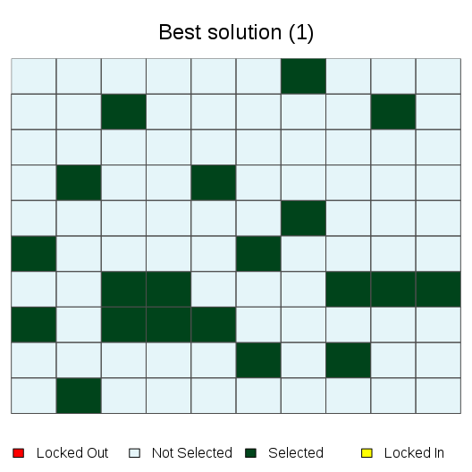

```r
# plot the prioritisation
plot(sim_rs_s1_space, 1)
```

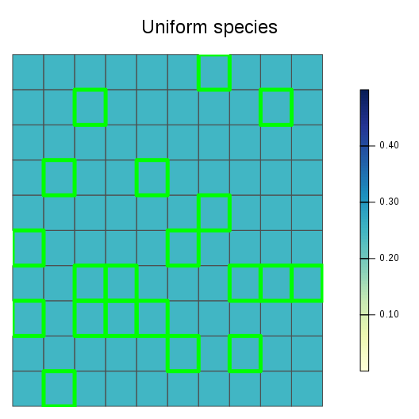

```r
# plot the prioritisation and the uniform species' distribution
spp.plot(sim_rs_s1_space, 'uniform', main='Uniform species')
```

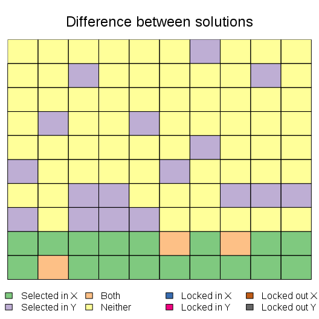

```r
# plot the difference between old and new prioritisations
plot(sim_rs_s1_amount, sim_rs_s1_space, 1, 1, main='Difference between solutions')
```

Here we can see that by including a space-target, the prioritisation is spread out evenly across the species’ distribution. Unlike the amount-based prioritisation, this prioritisation samples all the different parts of the species’ distribution.

Now, let’s generate a prioritisation for the normally distributed species that considers amount-based and space-based targets. Then, let’s visualise the new prioritisation and compare it to the old amount-based prioritisation.

```r
# make new prioritisation
sim_rs_s2_space <- update(sim_rs_s2_amount, amount.target=0.2, space.target=0.85)
```

```
## Optimize a model with 10102 rows, 10100 columns and 40100 nonzeros
## Coefficient statistics:
##   Matrix range    [1e-05, 5e+00]
##   Objective range [1e+00, 1e+00]
##   Bounds range    [1e+00, 1e+00]
##   RHS range       [1e+00, 3e+01]
## Found heuristic solution: objective 81
## Presolve time: 0.93s
## Presolved: 10102 rows, 10100 columns, 40100 nonzeros
## Variable types: 0 continuous, 10100 integer (10100 binary)
## Presolved: 10102 rows, 10100 columns, 40100 nonzeros
##
##
## Root relaxation: objective 1.297069e+01, 6719 iterations, 2.49 seconds
##
##     Nodes    |    Current Node    |     Objective Bounds      |     Work
##  Expl Unexpl |  Obj  Depth IntInf | Incumbent    BestBd   Gap | It/Node Time
##
##      0     0   12.97069    0  362   81.00000   12.97069  84.0%     -    3s
## H    0     0                      14.0000000   12.97069  7.35%     -    4s
##      0     0   12.97123    0  362   14.00000   12.97123  7.35%     -    5s
##
## Explored 0 nodes (7122 simplex iterations) in 7.27 seconds
## Thread count was 1 (of 2 available processors)
##
## Optimal solution found (tolerance 5.00e-02)
## Best objective 1.400000000000e+01, best bound 1.400000000000e+01, gap 0.0%
```

```r
# show summary
summary(sim_rs_s2_space)
```

```
##   Run_Number Score Cost Planning_Units Connectivity_Total Connectivity_In
## 1          1    14   14             14                220               4
##   Connectivity_Edge Connectivity_Out Connectivity_In_Fraction
## 1               168               48               0.01818182
```

```r
# show amount held
amount.held(sim_rs_s2_space)
```

```
##      normal
## 1 0.2154063
```

```r
# show space held
space.held(sim_rs_s2_space)
```

```
##   normal (Space 1)
## 1        0.8536759
```

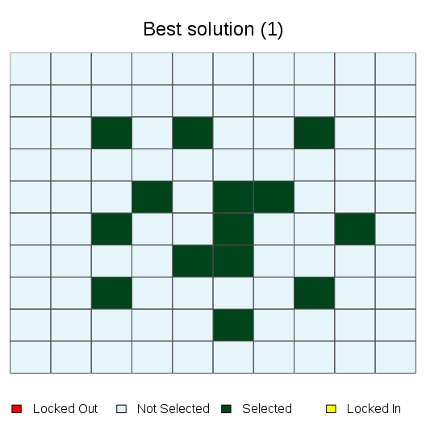

```r
# plot the prioritisation
plot(sim_rs_s2_space, 1)
```

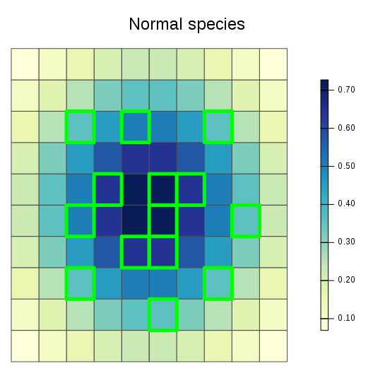

```r
# plot the prioritisation and the normal species' distribution
spp.plot(sim_rs_s2_space, 'normal', main='Normal species')
```

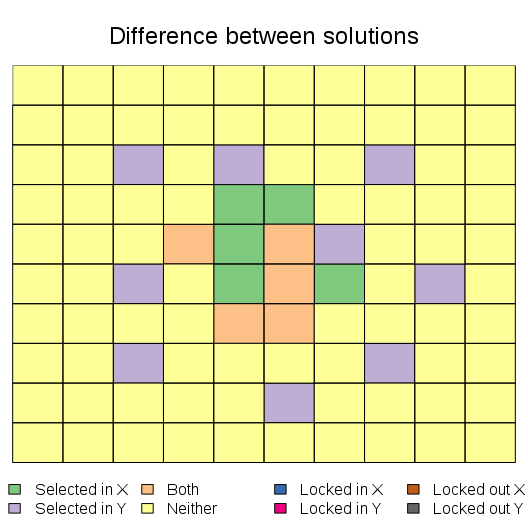

```r
# plot the difference between old and new prioritisations
plot(sim_rs_s2_amount, sim_rs_s2_space, 1, 1, main='Difference between solutions')
```

We can see by using both amount-based and space-based targets we can obtain a priortisation that secures both the species’ range core and parts of its range margin. As a consequence, it may capture any novel adaptations found along the species’ range margin–unlike the amount-based prioritisation.

Finally, let’s generate a prioritisation for the bimodal species using amount-based and space-based targets.

```r
# make new prioritisation
sim_rs_s3_space <- update(sim_rs_s3_amount, amount.target=0.2, space.target=0.85)
```

```
## Optimize a model with 10102 rows, 10100 columns and 40100 nonzeros
## Coefficient statistics:
##   Matrix range    [1e-05, 9e+00]
##   Objective range [1e+00, 1e+00]
##   Bounds range    [1e+00, 1e+00]
##   RHS range       [1e+00, 4e+01]
## Found heuristic solution: objective 79
## Presolve time: 0.90s
## Presolved: 10102 rows, 10100 columns, 40100 nonzeros
## Variable types: 0 continuous, 10100 integer (10100 binary)
## Presolved: 10102 rows, 10100 columns, 40100 nonzeros
##
##
## Root relaxation: objective 9.615676e+00, 8545 iterations, 3.11 seconds
##
##     Nodes    |    Current Node    |     Objective Bounds      |     Work
##  Expl Unexpl |  Obj  Depth IntInf | Incumbent    BestBd   Gap | It/Node Time
##
##      0     0    9.61568    0   35   79.00000    9.61568  87.8%     -    4s
## H    0     0                      10.0000000    9.61568  3.84%     -    4s
##
## Explored 0 nodes (8847 simplex iterations) in 4.33 seconds
## Thread count was 1 (of 2 available processors)
##
## Optimal solution found (tolerance 5.00e-02)
## Best objective 1.000000000000e+01, best bound 1.000000000000e+01, gap 0.0%
```

```r
# show summary
summary(sim_rs_s3_space)
```

```
##   Run_Number Score Cost Planning_Units Connectivity_Total Connectivity_In
## 1          1    10   10             10                220               3
##   Connectivity_Edge Connectivity_Out Connectivity_In_Fraction
## 1               183               34               0.01363636
```

```r
# show amount held
amount.held(sim_rs_s3_space)
```

```
##     bimodal
## 1 0.2107345
```

```r
# show space held
space.held(sim_rs_s3_space)
```

```
##   bimodal (Space 1)
## 1         0.8514121
```

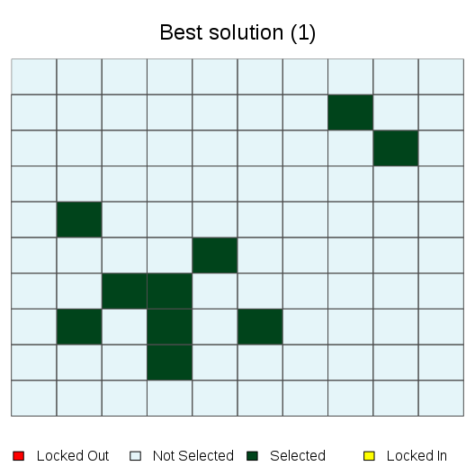

```r
# plot the prioritisation
plot(sim_rs_s3_space, 1)
```

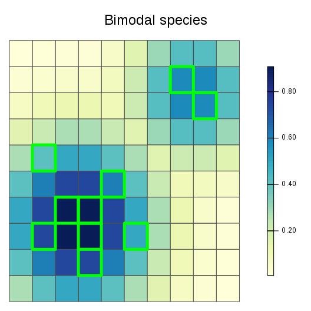

```r
# plot the prioritisation and the bimodal species' distribution
spp.plot(sim_rs_s3_space, 'bimodal', main='Bimodal species')
```

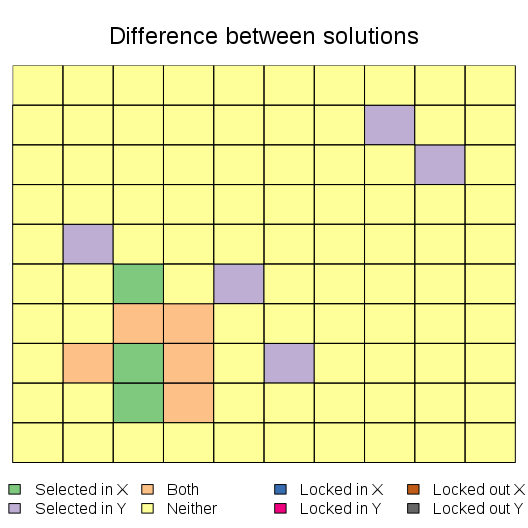

```r
# plot the difference between old and new prioritisations
plot(sim_rs_s3_amount, sim_rs_s3_space, 1, 1, main='Difference between solutions')
```

Earlier we found that the amount-based prioritisation only preserved individuals from a single ecotype, and would have failed to adequately preserve the intra-specific variation for this species. However, here we can see that by including space-based targets, we can develop prioritisations that the secure individuals belonging to both ecotypes. This new prioritisation is much more effective at sampling the intra-specific variation for this species.

Overall, these results demonstrate that under the simplest of conditions that the use of space-based targets can improve prioritisations. However, all these prioritisations were generated for a single species at a time. It is possible that by prioritisations generated using multiple species may do a better job at preserving the intra-specific variation for individuals species. We will investigate this in the next section.

### Multi-species prioritisations

So far we have generated prioritisations using only a single species at a time. However, real-world prioritisations are often generated for using multiple species to ensure that they preserve a comprehensive set of biodiversity. Here, we will generate multi-species prioritisations that preserve all three of the simulated species. First, we will generate a prioritisation using amount-based targets that only aims to preserve 20% of the area they occupy. Then, we will generate a prioritisation that also uses space-based targets to also preserve 85% of their geographic distribution. After doing this we will compare the two prioritisations.

```r
# make prioritisations
sim_mrs_amount <- update(sim_ru, amount.target=c(0.2,0.2,0.2), space.target=c(0,0,0))
```

```
## Optimize a model with 3 rows, 100 columns and 300 nonzeros
## Coefficient statistics:
##   Matrix range    [7e-03, 9e-01]
##   Objective range [1e+00, 1e+00]
##   Bounds range    [1e+00, 1e+00]
##   RHS range       [7e+00, 1e+01]
## Found heuristic solution: objective 27
## Presolve removed 0 rows and 45 columns
## Presolve time: 0.00s
## Presolved: 3 rows, 55 columns, 165 nonzeros
## Variable types: 0 continuous, 55 integer (10 binary)
## Presolved: 3 rows, 55 columns, 165 nonzeros
##
##
## Root relaxation: objective 2.000000e+01, 1 iterations, 0.00 seconds
##
##     Nodes    |    Current Node    |     Objective Bounds      |     Work
##  Expl Unexpl |  Obj  Depth IntInf | Incumbent    BestBd   Gap | It/Node Time
##
## *    0     0               0      20.0000000   20.00000  0.00%     -    0s
##
## Explored 0 nodes (1 simplex iterations) in 0.00 seconds
## Thread count was 1 (of 2 available processors)
##
## Optimal solution found (tolerance 5.00e-02)
## Best objective 2.000000000000e+01, best bound 2.000000000000e+01, gap 0.0%
```

```r
sim_mrs_space <- update(sim_ru, amount.target=c(0.2,0.2,0.2), space.target=c(0.85, 0.85, 0.85))
```

```
## Optimize a model with 30306 rows, 30100 columns and 120300 nonzeros
## Coefficient statistics:
##   Matrix range    [1e-05, 9e+00]
##   Objective range [1e+00, 1e+00]
##   Bounds range    [1e+00, 1e+00]
##   RHS range       [1e+00, 5e+01]
## Found heuristic solution: objective 100
## Presolve removed 0 rows and 0 columns (presolve time = 5s) ...
## Presolve time: 6.14s
## Presolved: 30306 rows, 30100 columns, 120300 nonzeros
## Variable types: 0 continuous, 30100 integer (30100 binary)
## Presolved: 30306 rows, 30100 columns, 120300 nonzeros
##
##
## Root simplex log...
##
## Iteration    Objective       Primal Inf.    Dual Inf.      Time
##        0    0.0000000e+00   4.070930e+02   0.000000e+00      7s
##     4477    2.0000071e+01   4.188072e+02   0.000000e+00     10s
##     8517    2.0000221e+01   1.960293e+02   0.000000e+00     15s
##    10909    2.0000368e+01   3.970013e+04   0.000000e+00     20s
##    12365    2.0000451e+01   1.046449e+04   0.000000e+00     25s
##    13286    2.0000000e+01   0.000000e+00   0.000000e+00     28s
##    13286    2.0000000e+01   0.000000e+00   0.000000e+00     28s
##
## Root relaxation: objective 2.000000e+01, 13286 iterations, 21.90 seconds
## Total elapsed time = 52.86s
##
##     Nodes    |    Current Node    |     Objective Bounds      |     Work
##  Expl Unexpl |  Obj  Depth IntInf | Incumbent    BestBd   Gap | It/Node Time
##
##      0     0   20.00000    0   23  100.00000   20.00000  80.0%     -   55s
## H    0     0                      21.0000000   20.00000  4.76%     -   55s
##
## Explored 0 nodes (27758 simplex iterations) in 55.26 seconds
## Thread count was 1 (of 2 available processors)
##
## Optimal solution found (tolerance 5.00e-02)
## Best objective 2.100000000000e+01, best bound 2.000000000000e+01, gap 4.7619%
```

```r
# show summaries
summary(sim_mrs_amount)
```

```
##   Run_Number Score Cost Planning_Units Connectivity_Total Connectivity_In
## 1          1    20   20             20                220              20
##   Connectivity_Edge Connectivity_Out Connectivity_In_Fraction
## 1               158               42               0.09090909
```

```r
summary(sim_mrs_space)
```

```
##   Run_Number Score Cost Planning_Units Connectivity_Total Connectivity_In
## 1          1    21   21             21                220              11
##   Connectivity_Edge Connectivity_Out Connectivity_In_Fraction
## 1               141               68                     0.05
```

```r
# show amount held for each prioritisation
amount.held(sim_mrs_amount)
```

```
##   uniform    normal   bimodal
## 1     0.2 0.2805844 0.3255251
```

```r
amount.held(sim_mrs_space)
```

```
##   uniform    normal   bimodal
## 1    0.21 0.2417393 0.2257705
```

```r
# show space held for each prioritisation
space.held(sim_mrs_amount)
```

```
##   uniform (Space 1) normal (Space 1) bimodal (Space 1)
## 1         0.7840732        0.8333445         0.8320986
```

```r
space.held(sim_mrs_space)
```

```
##   uniform (Space 1) normal (Space 1) bimodal (Space 1)
## 1           0.86966        0.8777045         0.8826188
```

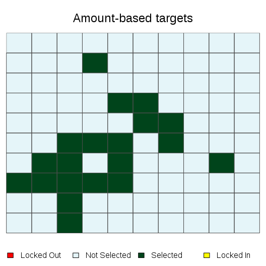

```r
# plot multi-species prioritisation with amount-based targets
plot(sim_mrs_amount, 1, main='Amount-based targets')
```

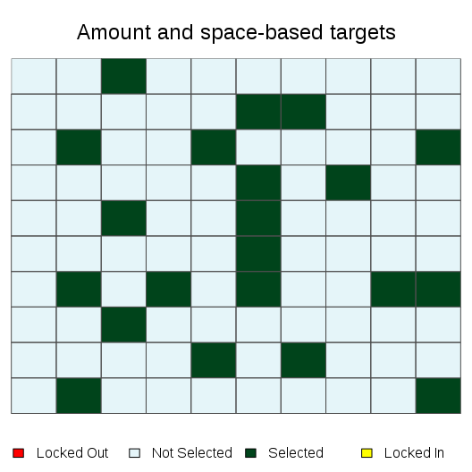

```r
# plot multi-species prioritisation with amount- and space-based targets
plot(sim_mrs_space, 1, main='Amount and space-based targets')
```

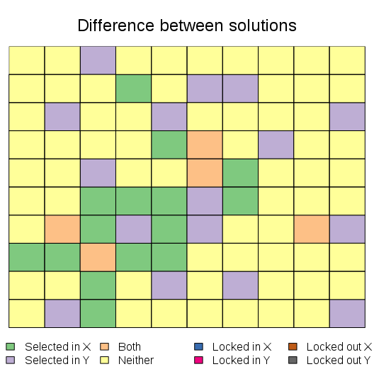

```r
# difference between the two prioritisations
plot(sim_mrs_amount, sim_mrs_space, 1, 1, main='Difference between solutions')
```

Here we can see that the inclusion of space-based targets changes which planning units are selected for prioritisation, but also the number of planning units that are selected. The amount-based prioritistion is comprised of 20 units, and the space-based prioritisation is comprised of 21 units. This result suggests that a adequate and representative prioritisation can be acheived for only a minor increase in cost.